# Using the `countyweather` package

## Writing out timeseries files

There are a few functions that allow the user to write out daily or hourly timeseries datasets for many different counties to a specified local directory, as well as plots of this data. For daily weather data, see the functions `write_daily_timeseries` and `plot_daily_timeseries`. For hourly, see `write_hourly_timeseries` and `plot_hourly_timeseries`.

For example, if we wanted to compare daily weather in the month of August for three counties in southern Florida, we could run:

```r
fl_counties <- c("12086", "12087", "12011")

write_daily_timeseries(fips = fl_counties, date_min = "1992-08-01",
                 date_max = "1992-08-31", var = "prcp",
                 out_directory = "~/Documents/andrew_data")
```

The `write_daily_timeseries` function saves each county’s timeseries as a separate file in a subdirectory called “data” of the directory specified in the `out_directory` option. The `data_type` argument allows the user to specify either .rds or .csv files (the default is to write .rds files). Each file is a time series dataframe of daily weather data. A dataframe of station metadata is saved in a second subdirectory called “metadata”, and maps showing locations of weather stations contributing to each time series are saved in a subdirectory called “maps.” At this stage, if you were to include a county in the `fips` argument without available data, a file would not be created for that county.

The function `plot_daily_timeseries` creates and saves plots for each of these files. (Note: the `data_type` argument for this function also defaults to read .rds files, so if you chose to write .csv files, make sure to change that arugment in this function as well to `data_type = "csv"`.)

```r
plot_daily_timeseries("prcp", data_directory = "~/Documents/andrew_data/data",
                      plot_directory = "~/Documents/andrew_data/plots",
                      date_min = "1992-08-01", date_max = "1992-08-31")
```

Here’s an example of what the timeseries plots for the three Florida counties would look like:

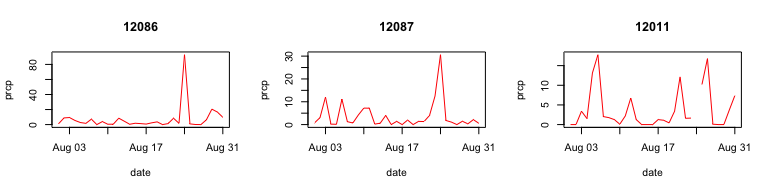

## Futher options available in the package

### `coverage`

For `hourly_fips`, `daily_fips`, and time series functions, the user can choose to filter out any stations that report variables for less than a certain percent of the specified date range (`coverage`). For example, if you were to set `coverage` to 0.90, only stations that reported non-missing values at least 90% of the time over the specified date range would be included in your data.

### `average_data`

In both `daily_fips` and `hourly_fips`, the default is to return a single daily average for the county for each day in the timeseries, giving the value averaged across all available stations on that day. However, there is also an option called `average_data` which allows the user to specify whether they would like the weather data returned before it has been averaged across stations. If this argument is set to `FALSE`, the functions will return separate daily data for each station in the county. For our Hurricane Andrew example, we can specify `average_data = FALSE`:

```r
not_averaged <- daily_fips(fips = "12086",
                           date_min = "1992-08-01",
                           date_max = "1992-08-31",
                           var = "prcp", average_data = FALSE,
                           station_label = TRUE)
```

```r
not_averaged_data <- not_averaged$daily_data
head(not_averaged_data)
## # A tibble: 6 × 3
##            id       date  prcp
##         <chr>     <date> <dbl>
## 1 USC00083909 1992-08-01   1.3
## 2 USC00083909 1992-08-02   4.8
## 3 USC00083909 1992-08-03   1.3
## 4 USC00083909 1992-08-04   0.0
## 5 USC00083909 1992-08-05   7.6
## 6 USC00083909 1992-08-06   1.0
unique(not_averaged_data$id)
## [1] "USC00083909" "USC00087020" "USC00088780" "USW00012839" "USW00012859"
## [6] "USW00092811"
```

In this example, there are six stations contributing weather data to the timeseries. We can plot the data by station to get a sense for how values from each station compare, and which stations were presumably knocked out by the storm, with different colors used to show values for different stations:

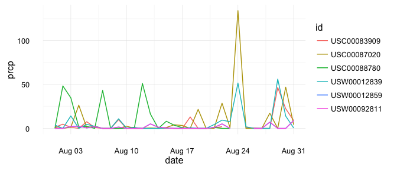

```r
library(ggplot2)
ggplot(not_averaged_data, aes(x = date, y = prcp,
                         colour = id)) +
  geom_line() +
  theme_minimal()
```

It might be interesting here to compare this plot with the station map, this time with station labels included (done using `station_label = TRUE` when we pulled this data using `daily_fips`):

[figure not shown]

```r
not_averaged$station_map
```

### Quality Flags

The hourly Integrated Surface Data includes quality codes for each of the main weather variables. For more information about the hourly weather variables, see the “More on the weather data” section below. We can use these codes to remove suspect or erroneous values from our data. The values in `wind_speed_quality`, for example, take on the following values: (Values in this table were pulled from the ISD documentation file.)

| code | definition |
| --- | --- |
| 0 | Passed gross limits check |
| 1 | Passed all quality control checks |
| 2 | Suspect |
| 3 | Erroneous |
| 4 | Passed gross limits check , data originate from an NCEI data source |
| 5 | Passed all quality control checks, data originate from an NCEI data source |
| 6 | Suspect, data originate from an NCEI data source |
| 7 | Erroneous, data originate from an NCEI data source |
| 9 | Passed gross limits check if element is present |

Because it doesn’t make sense to average these codes across stations, the codes should only be pulled when using the option to pull station-specific values (`average_data = FALSE`).

```r
ex <- hourly_fips("12086", 1992, var = c("wind_speed", "wind_speed_quality"),
                  average_data = FALSE)
```

```r
ex_data <- ex$hourly_data
head(ex_data)
## # A tibble: 6 × 7
##   usaf_station wban_station           date_time latitude longitude
##          <dbl>        <dbl>              <dttm>    <dbl>     <dbl>
## 1       722029           NA 1992-01-01 00:00:00    25.65   -80.433
## 2       722029           NA 1992-01-01 01:00:00    25.65   -80.433
## 3       722029           NA 1992-01-01 02:00:00    25.65   -80.433
## 4       722029           NA 1992-01-01 03:00:00    25.65   -80.433
## 5       722029           NA 1992-01-01 04:00:00    25.65   -80.433
## 6       722029           NA 1992-01-01 05:00:00    25.65   -80.433
## # ... with 2 more variables: wind_speed <dbl>, wind_speed_quality <chr>
```

We can replace all wind speed observations with quality codes of 2, 3, 6, or 7 with `NA`s.

```r
ex_data$wind_speed_quality <- as.numeric(ex_data$wind_speed_quality)
ex_data$wind_speed[ex_data$wind_speed_quality %in% c(2, 3, 6, 7)] <- NA
```

## More on the weather data

### Daily weather data

Functions in this package that pull daily weather values (`daily_fips()`, for example) are pulling data from the Daily Global Historical Climatology Network (GHCN-Daily) through NOAA’s FTP server. The data is archived at the National Centers for Environmental Information (NCEI) (formerly the National Climatic Data Center (NCDC)), and spans from the 1800s to the current year.

Users can specify which weather variables they would like to pull. The five core daily weather variables are precipitation (`prcp`), snowfall (`snow`), snow depth (`snwd`), maximum temperature (`tmax`) and minimum temperature (`tmin`). The daily weather data is filtered so that included weather variables fall within a range of possible values. These ranges were chosen to include national maximum recorded values.

| Variable | Description | Units | Most extreme value |
| --- | --- | --- | --- |
| prcp | precipitation | mm | 1100 mm |
| snow | snowfall | mm | 1600 mm |
| snwd | snow depth | mm | 11500 mm |
| tmax | maximum temperature | degrees Celsius | 57 degrees C |
| tmin | minumum temperature | degrees Celsius | -62 degrees C |

`tmax`, `tmin`, and `prcp` were originally recorded in tenths of units, and are listed as such in NOAA documentation. These values are converted to standard units (degrees Celsius and mm, respectively) in `countyweather` output.

There are several additional, non-core variables available. For example, `acmc` gives the “average cloudiness midnight to midnight from 30-second ceilometer data (percent).” The complete list of available weather variables can be found under ‘element’ from the GHCND’s [readme file](http://www1.ncdc.noaa.gov/pub/data/ghcn/daily/readme.txt).

While the datasets resulting from functions in this package return a cleaned and aggregated dataset, Menne et al. (2012) give more information aboout the raw data in the GHCND database.

### Hourly weather data

Hourly weather data in this package is pulled from NOAA’s Integrated Surface Data (ISD), and is available from 1901 to the current year. The data is archived at the National Centers for Environmental Information (NCEI) (formerly the National Climatic Data Center (NCDC)), and is also pulled through NOAA’s FTP server.

The seven core hourly weather variables are `wind_direction`, `wind_speed`, `ceiling_height`, `visibility_distance`, `temperature`, `temperature_dewpoint`, and `air_pressure`. Values in this table were pulled from the ISD documentation file.

| Variable | Description | Units | Minimum | Maximum |
| --- | --- | --- | --- | --- |
| wind_direction | The angle, measured in a clockwise direction, between true north and the direction from which the wind is blowing | Angular Degrees | 1 | 360 |
| wind_speed | The rate of horizontal travel of air past a fixed point | Meters per Second | 0 | 90 |
| ceiling_height | The height above ground level of the lowest cloud or obscuring phenomena layer aloft with 5/8 or more summation total sky cover, which may be predominately opaque, or the vertical visibility into a su… | Meters | 0 | 22000 (indicates ‘Unlimited’) |
| visibility_distance | The horizontal distance at which an object can be seen and identified | Meters | 0 | 160000 |
| temperature | The temperature of the air | Degrees Celsuis | -93.2 | 61.8 |
| temperature_dewpoint | The temperature to which a given parcel of air must be cooled at constant pressure and water vapor content in order for saturation to occur | Degrees Celsius | -98.2 | 36.8 |
| air_pressure | The air pressure relative to Mean Sea Level | Hectopascals | 860 | 1090 |

There are other columns available in addition to these weather variables, such as quality codes (e.g., `wind_direction_quality` — each of the main weather variables has a corresponding quality code that can be pulled by adding `_quality` to the end of the variable name).

For more information about the weather variables described in the above table and other available columns, see the ISD documentation file.

## Error and warning messages you may get

### Not able to pull data from a station

The following error message will come up after running functions pulling daily data if there isn’t available data (for your specified date range, coverage, and weather variables) for a particular station or stations:

`In rnoaa::meteo_pull_monitors(monitors = stations, keep_flags = FALSE,: The following stations could not be pulled from the GHCN ftp:` `USR0000FTEN` `Any other monitors were successfully pulled from GHCN.`

The following error message will come up after running functions pulling hourly data (`hourly_fips()`) if there isn’t available data for any of the stations in your specified county. Note: some weather variables tend to be missing more often than others.

`Error in isd_monitors_data(fips = fips, year = x, var = var, radius = radius): None of the stations had available data.`

The following error message will come up after running `write_daily_timeseries` or `write_hourly_timeseries` if the function is unable to pull data for a particular fips code in your `fips` vector:

`Unable to pull weather data for FIPS code "(specified fips code)" for the specified percent coverage, year(s), and/or weather variables.`

### Need an API key for NOAA data

If you run functions that use NOAA API calls without first requesting an API key from NOAA and setting up the key in your R session, you will see the following error message:

```r
Error in getOption("noaakey", stop("need an API key for NOAA data")) :
  need an API key for NOAA data
```

You might also see this warning message:

```r
Warning message:
Error: (400) - Token parameter is required.
```

If you get one of these messages, run the code:

```r
options("noaakey" = Sys.getenv("noaakey"))
```

and then try again. If you still get an error, you may not have set up your NOAA API key correctly in your `.Renviron` file. See the “Required set-up” section of this document for more details on doing that correctly.

### NOAA web services down

Sometimes, some of NOAA’s web services will be off-line. In this case, you may get an error message when you try to pull data like:

```
Error in gzfile(file, mode) : cannot open the connection
```

or

```
Error in tt$results : $ operator is invalid for atomic vectors In addition: Warning message:
Error: (500) - An error occured while servicing your request.
```

In this case, re-starting your R session might fix the problem. If not, wait a few hours and then try again.

### Other errors

If you get other error messages or run into problems with this package, please submit a reproducible example on this repository’s Issues page.

## References

Menne, Matthew J, Imke Durre, Russell S Vose, Byron E Gleason, and Tamara G Houston. 2012. “An Overview of the Global Historical Climatology Network-Daily Database.” *Journal of Atmospheric and Oceanic Technology* 29 (7): 897–910.